# Michigan PFAS Analysis

### Visualizing sampling effort based on month

```r
samples_site_df <- samples_site_df |>
  mutate(
    month_name = month(sample_date, label = TRUE, abbr = FALSE)
  )
```

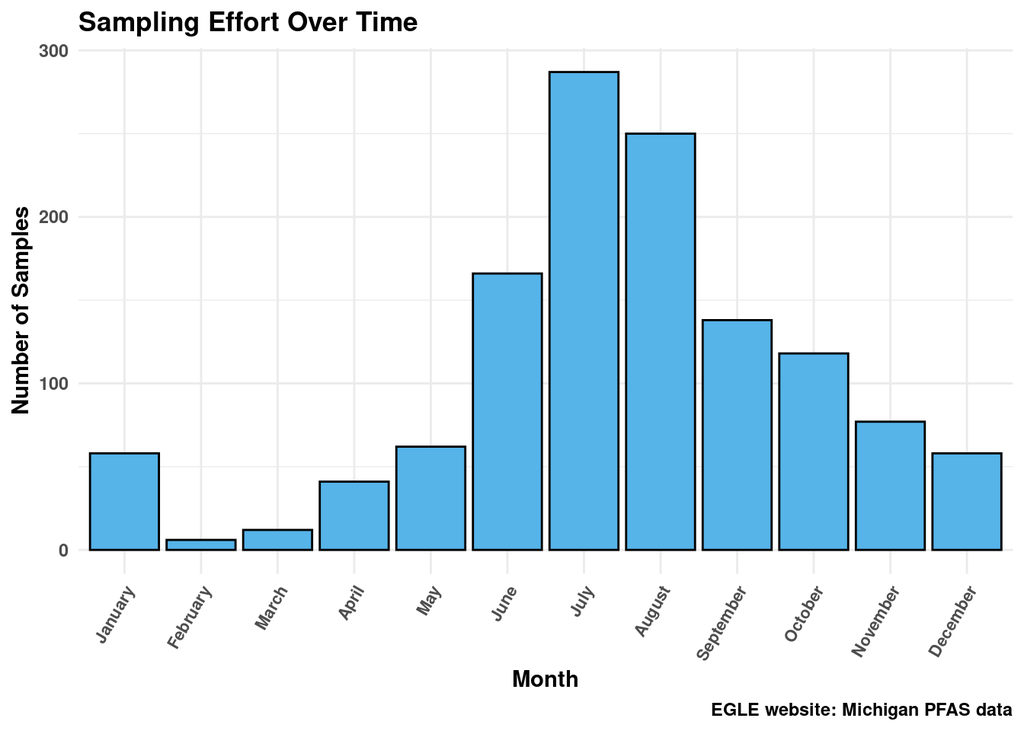

```r
bar_date <- samples_site_df |>
  filter(!is.na(month_name)) |>
  count(month_name) |>
  ggplot(aes(x = month_name, y = n)) +
  geom_col(color = "black",fill = "#56B4E9") + # #56B4E9 is color blind friendly blue
  labs(
    title = "Sampling Effort Over Time",
    x = "Month",
    y = "Number of Samples",
    caption = "EGLE website: Michigan PFAS data"
  ) +
  theme_minimal() +
  theme(
    axis.text.x = element_text(angle = 60, hjust = 1, size = 8),
    text = element_text(face = "bold")
  )

bar_date
```

From the visualization above, we can notice the seasonal pattern on the sampling effort. June-August shows higher sampling activity, which suggests summer months are more active in terms of the sampling effort. Winter months (January-May) show reduction in compared to peak summer months whereas fall season seems to be m more active than the winter season.

# Permuation or Randomization Test

```r
samples_site_df |>
  group_by(nearest_facility) |>
  summarize(mean_hazard_index = mean(hazard_index, na.rm=TRUE),
            var = var(hazard_index, na.rm=TRUE),
            number_of_samples = n()) |>
  filter(number_of_samples > 5 & mean_hazard_index > 0.5) |>
  flextable()
```

| nearest_facility | mean_hazard_index | var | number_of_samples |
| --- | --- | --- | --- |
| 120th Avenue Area | 0.9916900 | 5.056544 | 10 |
| Ben Powell Landfill (Also Known As Clarkston Landfill) | 0.6847500 | 2.085807 | 6 |
| Cherry Capital Airport | 2.6720000 | 20.952155 | 7 |
| Crown Vantage Property | 0.8012500 | 3.849126 | 6 |
| Manistee Blacker Airport | 0.7309615 | 6.632004 | 13 |
| Pellston Regional Airport | 1.7237381 | 57.215416 | 21 |
| Stanton Wastewater Treatment Plant | 0.5791750 | 2.544337 | 10 |

```r
# Calculating standard deviations and variances for each group
trial_data <- samples_site_df |>
  filter(nearest_facility %in% c("Pellston Regional Airport", "Manistee Blacker Airport"))

trial_data <- trial_data |>
  dplyr::mutate(facility = fct_relevel(nearest_facility, "Pellston Regional Airport", "Manistee Blacker Airport")) |>
  select(facility, hazard_index)

trial_data |>
  group_by(facility) |>
  summarize(Mean = mean(hazard_index),
            n = n(),
            SD = sd(hazard_index),
            Variance = var(hazard_index)) |>
  flextable() |>
  colformat_double(digits = 3) |>
  autofit()
```

| facility | Mean | n | SD | Variance |
| --- | --- | --- | --- | --- |
| Pellston Regional Airport | 1.724 | 21 | 7.564 | 57.215 |
| Manistee Blacker Airport | 0.731 | 13 | 2.575 | 6.632 |

```r
# Two-sample t-test
ttest_result <- t.test(formula = hazard_index ~ facility,
                       data = trial_data,
                       alternative = "greater")
```

```r
# Number of permutations to do
n_permutations <- 5000

# Instantiating vector for test statistics
permutation_statistics <- vector(length = n_permutations)

# Calculating t-test statistic for each permutation
for(p in 1:n_permutations) {
  permutation_statistics[p] <- t.test(formula = hazard_index ~ facility,
                                      alternative = "greater",
                                      data = trial_data |>
    mutate(facility = sample(facility, replace = FALSE))) |>
    broom::tidy() |>
    pull(statistic)
}
```

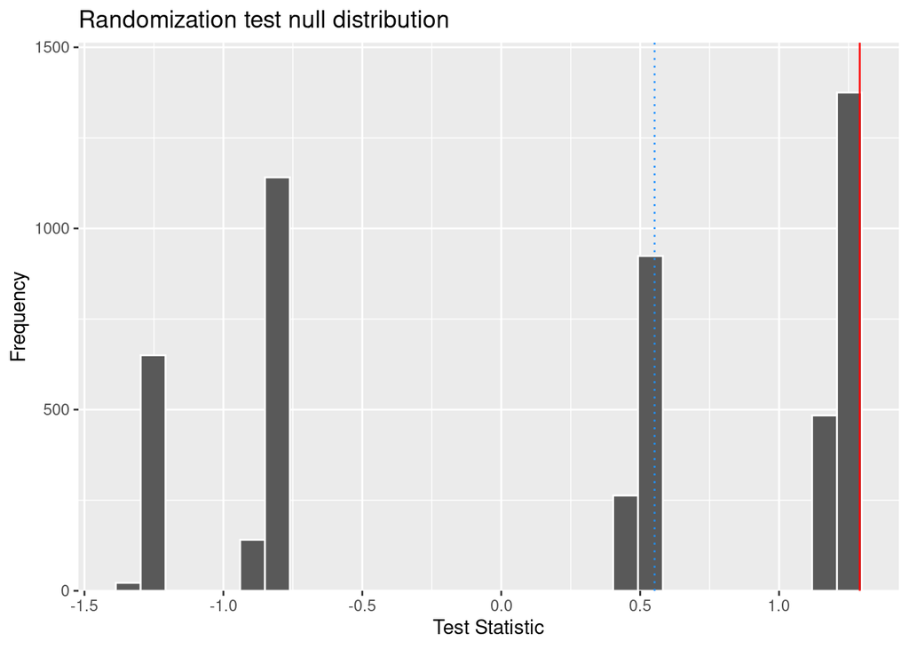

```r
tibble(t_stat = permutation_statistics)|>
  ggplot(aes(x = t_stat)) +
  geom_histogram(color = "white") +
  scale_y_continuous(expand = expansion(mult = c(0, 0.1))) +
  geom_vline(xintercept = quantile(permutation_statistics,
                                   probs = 0.95),
             color = "red", linetype = "solid") +
  geom_vline(xintercept = ttest_result$statistic,
             color = "dodgerblue", linetype = "dotted") +
  labs(title = "Randomization test null distribution",
       x = "Test Statistic",
       y = "Frequency")
```

```r
janitor::tabyl(permutation_statistics >= ttest_result$statistic)
```

```
 permutation_statistics >= ttest_result$statistic    n percent
                                            FALSE 2795   0.559
                                             TRUE 2205   0.441
```

**Formal Statement of our hypothesis for the randomization test**

Our hypothesis are given by

$$H_0 : \mu_{Pellston} = \mu_{Manistee}$$

$$H_a : \mu_{Pellston} > \mu_{Manistee}$$

where, $\mu_{Pellston}$ is the average hazard index of the Pellston Regional Airport site, and $\mu_{Manistee}$ is the average hazard index of the Manistee Blacker Airport site.

**Interpretation in context**: We don’t have enough statistical evidence to conclude that the mean hazard index is different between Pellston Regional Airport and Manistee Blacker Airport. The observed difference could reasonably be due to random chance.

# Conclusion

In this project, we combined two PFAS-related datasets—one describing contamination sites and one describing drinking water samples—to explore spatial and temporal patterns of PFAS hazard in Michigan. We began by inspecting data quality and patterns of missingness, then dropped variables with large amounts of missing data that were not essential to our analysis (`site_background`, `drinking_water_information`, `anticipated_activities`, and `location`). We also addressed missing GEOID values in the sampling dataset by assigning each point to the nearest county using spatial proximity. Visual inspection of the map confirmed that these samples tended to fall just outside county boundaries, so nearest-county imputation was a reasonable, if imperfect, choice.

Our exploratory analysis showed that most hazard index (HI) values were low, with a highly right-skewed distribution and a large concentration of samples below the EPA threshold of concern (HI < 1). However, a small number of sites and counties exhibited much higher maximum hazard index values, indicating localized contamination hotspots that may warrant closer monitoring or remediation. County-level summaries revealed that a few counties have many more samples than others, and the bar chart of samples per county highlighted clear disparities in monitoring effort. Some large counties had relatively few samples, suggesting potential gaps in spatial coverage.

At the site level, we examined both the number of samples and the maximum hazard index. When we plotted the top 50 sites with point size representing maximum hazard index, the sizes appeared to be spread fairly uniformly across sites ordered by sample count. This suggests there is little systematic relationship between monitoring intensity (number of samples) and contamination severity (maximum HI). In other words, sites with more samples do not consistently show higher hazard indices. However, there is an important exception: the site associated with the single highest hazard index does have a relatively large number of samples, indicating that some high-risk locations may indeed draw more monitoring attention.

We also examined temporal patterns in sampling effort. The plot of sampling counts by month (Figure 2: sampling effort by month) showed a clear seasonal pattern, with more intensive sampling in the summer months (June–August) and reduced activity in winter. This pattern likely reflects practical field constraints (e.g., weather and access) as well as monitoring priorities. The `years_since_sample` variable further emphasized that some samples are relatively old, which is important when interpreting current risk and planning future monitoring.

Finally, we conducted a permutation (randomization) test comparing hazard index values at Pellston Regional Airport and Manistee Blacker Airport. Although Pellston showed a higher mean hazard index and much greater variability, the permutation test failed to reject the null hypothesis at the 5% significance level. This suggests that, given the variability and sample sizes, we do not have strong statistical evidence that Pellston’s mean hazard index is truly higher than Manistee’s—it could plausibly be due to random variation. This result underscores the importance of considering both effect size and variability, and not relying solely on raw differences in means.

Overall, our analysis paints a nuanced picture: most drinking water samples in Michigan show low PFAS hazard indices, but there are notable hotspots, uneven sampling across space and time, and nontrivial uncertainty in how samples are linked to specific facilities and counties. These limitations mean that our findings should be interpreted with caution.

# Contributions of each group member

All members contributed equally to the planning and overall success of the project. Nishan and Kabin collaborated on designing the data transformation strategy, with Nishan carrying out most of the coding for its implementation. The entire group contributed to planning, while Udita mainly contributed to the implementation of data cleaning and exploratory data analysis. Nishan and Kabin worked together to design the layout and functionality of the interactive dashboard, with Kabin primarily implementing it in code. Each member documented their respective components to ensure clarity and reproducibility. Udita also ensured that the final project satisfied all requirements outlined in the rubric and follows provided structure. Most implementation tasks were completed collaboratively in pairs, reinforcing shared understanding and joint problem-solving throughout the project.

# Dashboard Code

```r
#|eval: false

library(shiny)
library(leaflet)
library(plotly)
library(ggplot2)
library(dplyr)


samples_site_df <- read_csv("data/samples_site.csv")

# Sites and their sample locations
sites_dash <- samples_site_df |>
  mutate(site = nearest_facility,
         lat = latitude.y,
         lon = longitude.y) |>
  group_by(site, lat, lon) |>
  summarize(max_hazard_index = max(hazard_index, na.rm = TRUE)) |>
  select(site, lat, lon, max_hazard_index) |>
  dplyr::distinct()

samples_dash <- samples_site_df |>
  mutate(site = nearest_facility,
         sample_name = system_name,
         lat = latitude.x,
         lon = longitude.x) |>
  select(site, sample_name, lat, lon, pfhxs_result, pfna_result, hfpoda_result, pfbs_result, hazard_index)

# UI
ui <- fluidPage(
  titlePanel("Michigan PFAS Dashboard"),

  sidebarLayout(
    sidebarPanel(
      width = 4,
      h4("Instructions"),
      p("Click on a site marker to zoom in and view samples for that site."),
      actionButton("reset_view", "Reset Map View",
                   class = "btn-primary",
                   style = "margin-top: 10px;"),
      actionButton("view_report", "View Analysis Report",
                   class = "btn-info",
                   style = "margin-top: 10px;"),
      hr(),
      uiOutput("site_info")
    ),

    mainPanel(
      width = 8,
      leafletOutput("main_map", height = "400px"),
      hr(),
      fluidRow(
        column(6,
               conditionalPanel(
                 condition = "output.has_nonzero_samples",
                 plotlyOutput("plot1", height = "350px")
               ),
               conditionalPanel(
                 condition = "!output.has_nonzero_samples",
                 div(style = "padding: 50px; text-align: center;",
                     h4("All samples from this site are safe (Hazard Index = 0)"))
               )
        ),
        column(6,
               conditionalPanel(
                 condition = "output.has_nonzero_samples",
                 plotlyOutput("plot2", height = "350px")
               )
        )
      )
    )
  )
)

# Server
server <- function(input, output, session) {

  # Reactive value to store selected site
  selected_site <- reactiveVal(NULL)



  # In your server function
  sites_hazard_color <- function(hazard_index) {
    sapply(hazard_index, function(hi) {
      if (hi == 0) {
        return("#c0c0c0")  # Blue for zero
      } else if (hi > 0 && hi <= 1) {
        return("#FFE08F")  # Yellow for 0-1
      } else {
        # Gradient from orange to red for values > 1
        max_hi <- max(sites_dash$max_hazard_index, na.rm = TRUE)
        ratio <- min((hi - 1) / (max_hi - 1), 1)

        colorRampPalette(c("#FF6C0C", "red"))(100)[round(ratio * 99) + 1]
      }
    })
  }

  samples_hazard_color <- function(hazard_index) {
    sapply(hazard_index, function(hi) {
      if (hi == 0) {
        return("#000000")  # Black for zero for visibility
      } else if (hi > 0 && hi <= 1) {
        return("#FFE08F")  # Yellow for 0-1
      } else {
        # Gradient from orange to red for values > 1
        max_hi <- max(samples_dash$hazard_index, na.rm = TRUE)
        ratio <- min((hi - 1) / (max_hi - 1), 1)

        colorRampPalette(c("#FF6C0C", "red"))(100)[round(ratio * 99) + 1]
      }
    })
  }


  # Initial map render
  output$main_map <- renderLeaflet({
    leaflet() |>
      addTiles() |>
      clearControls() |> # Clear old legend first
      addLegend(
        position = "bottomright",
        colors = c("#c0c0c0", "#000000", "#FFE08F", "#FF6C0C", "red"),
        labels = c("HI = 0 (site)", "HI = 0 (sample)", "0 < HI ≤ 1", "HI > 1 (lower)", "HI > 1 (higher)"),
        title = "Hazard Index",
        opacity = 1
      ) |>
      addPolygons(
        data = mi_counties,
        color = "#A2AF9B",
        weight = 1,
        fillOpacity = 0,
        label = ~NAME
      ) |>
      addCircleMarkers(
        data = sites_dash,
        lng = ~lon,
        lat = ~lat,
        layerId = ~site,
        radius = 6,
        color = ~sites_hazard_color(max_hazard_index),
        fillColor = ~sites_hazard_color(max_hazard_index),
        fillOpacity = 0.5,
        popup = ~paste("<b>", site, "</b><br>Click to view samples")
      ) |>
      setView(
        lng = mean(c(min(sites_dash$lon), max(sites_dash$lon))),
        lat = mean(c(min(sites_dash$lat), max(sites_dash$lat))),
        zoom = 6
      )
  })

  # Handle report viewing
  observeEvent(input$view_report, {
    showModal(modalDialog(
      title = "Analysis Report",
      size = "l",  # large modal
      easyClose = TRUE,
      footer = modalButton("Close"),
      tags$iframe(
        src = "./www/Final_project.html",
        width = "100%",
        height = "600px",
        frameborder = 0
      )
    ))
  })

  # Handle site marker clicks
  observeEvent(input$main_map_marker_click, {
    click <- input$main_map_marker_click

    if (!is.null(click$id)) {
      site_name <- click$id
      selected_site(site_name)

      # Get site and sample data
      selected_site_data <- sites_dash |> filter(site == site_name) # only one
      sample_dash_subset <- samples_dash |> filter(site == site_name)

      # Update map: zoom to site and show samples
      map_proxy <- leafletProxy("main_map") |>
        clearMarkers() |>
        clearShapes() |>
        clearControls() |> # Clear old legend first
        addLegend(
          position = "bottomright",
          colors = c("#c0c0c0", "#000000", "#FFE08F", "#FF6C0C", "red"),
          labels = c("HI = 0 (site)", "HI = 0 (sample)", "0 < HI ≤ 1", "HI > 1 (lower)", "HI > 1 (higher)"),
          title = "Hazard Index",
          opacity = 1
        ) |>
        addPolygons(
          data = mi_counties,
          color = "#A2AF9B",
          weight = 1,
          fillOpacity = 0,
          label = ~NAME
        ) |>
        addCircleMarkers(
          data = sites_dash,
          lng = ~lon,
          lat = ~lat,
          layerId = ~site,
          radius = 6,
          color = ~sites_hazard_color(max_hazard_index),
          fillColor = ~sites_hazard_color(max_hazard_index),
          fillOpacity = 0.5,
          popup = ~paste("<b>", site, "</b><br>Click to view samples")
        ) |>
        addCircleMarkers(
          data = sample_dash_subset,
          lng = ~lon,
          lat = ~lat,
          radius = 2,
          color = ~samples_hazard_color(hazard_index),
          fillColor = ~samples_hazard_color(hazard_index),
          fillOpacity = 1,
          popup = ~paste("<b>", sample_name, "</b><br>",
                         "Hazard Index:", round(hazard_index, 2))
        )
      # Add lines connecting site to each sample
      for (i in 1:nrow(sample_dash_subset)) {
        map_proxy <- map_proxy |>
          addPolylines(
            lng = c(selected_site_data$lon, sample_dash_subset$lon[i]),
            lat = c(selected_site_data$lat, sample_dash_subset$lat[i]),
            color = "gray",
            weight = 2,
            opacity = 0.5,
            dashArray = "5, 5"
          )
      }

      map_proxy |>
        fitBounds(
          lng1 = min(c(sample_dash_subset$lon,selected_site_data$lon), na.rm = TRUE),
          lat1 = min(c(sample_dash_subset$lat,selected_site_data$lat), na.rm = TRUE),
          lng2 = max(c(sample_dash_subset$lon,selected_site_data$lon), na.rm = TRUE),
          lat2 = max(c(sample_dash_subset$lat,selected_site_data$lat), na.rm = TRUE)
        )
    }
  })

  # Reset map view
  observeEvent(input$reset_view, {
    selected_site(NULL)

    leafletProxy("main_map") |>
      clearMarkers() |>
      addTiles() |>
      clearControls() |> # Clear old legend first
      addLegend(
        position = "bottomright",
        colors = c("#c0c0c0", "#000000", "#FFE08F", "#FF6C0C", "red"),
        labels = c("HI = 0 (site)", "HI = 0 (sample)", "0 < HI ≤ 1", "HI > 1 (lower)", "HI > 1 (higher)"),
        title = "Hazard Index",
        opacity = 1
      ) |>
      addCircleMarkers(
        data = sites_dash,
        lng = ~lon,
        lat = ~lat,
        layerId = ~site,
        radius = 6,
        color = ~sites_hazard_color(max_hazard_index),
        fillColor = ~sites_hazard_color(max_hazard_index),
        fillOpacity = 0.5,
        popup = ~paste("<b>", site, "</b><br>Click to view samples")
      ) |>
      setView(
        lng = mean(c(min(sites_dash$lon), max(sites_dash$lon))),
        lat = mean(c(min(sites_dash$lat), max(sites_dash$lat))),
        zoom = 6
      )
  })

  # Site info panel
  output$site_info <- renderUI({
    if (is.null(selected_site())) {
      div(
        h5("No site selected"),
        p("Click on a site marker to view details.")
      )
    } else {
      site_samples <- samples_dash |> filter(site == selected_site())
      div(
        h4(paste("Site:", selected_site())),
        p(strong("Number of samples:"), nrow(site_samples)),
        p(strong("Min hazard index:"), round(min(site_samples$hazard_index, na.rm=TRUE), 2)),
        p(strong("Max hazard index:"), round(max(site_samples$hazard_index, na.rm=TRUE), 2)),
        p(strong("Mean hazard index:"), round(mean(site_samples$hazard_index, na.rm=TRUE), 2)),
        p(strong("Standard deviation hazard index:"), round(sd(site_samples$hazard_index, na.rm=TRUE), 2)),
        p(strong("Median hazard index:"), round(median(site_samples$hazard_index, na.rm=TRUE), 2)),
      )
    }
  })

  # Add this reactive to check for non-zero samples
  output$has_nonzero_samples <- reactive({
    if (is.null(selected_site())) {
      return(TRUE)  # Show default plots when no site selected
    }

    nonzero_count <- samples_dash %>%
      filter(site == selected_site() & hazard_index > 0) %>%
      nrow()

    return(nonzero_count > 0)
  })

  outputOptions(output, "has_nonzero_samples", suspendWhenHidden = FALSE)

  # First plot
  output$plot1 <- renderPlotly({
    if (is.null(selected_site())) {

      first_plot <- dist_hazard

    } else {
      first_plot <- samples_dash |>
        filter(site == selected_site()) |>
        ggplot(aes(y = hazard_index)) +
        geom_boxplot() +
        labs(title = str_glue("Distribution of Hazard Index for {selected_site()}"),
             y = "Hazard Index")

    }
    ggplotly(first_plot) |>
      layout(
        xaxis = list(autorange = TRUE),
        yaxis = list(autorange = TRUE)
      )
  })

  # Second Plot
  output$plot2 <- renderPlotly({
    if (is.null(selected_site())) {

      second_plot <- bar_date

    } else {
      samples_dash_scaled <- samples_dash |>
        filter(site == selected_site() & hazard_index > 0) |>
        mutate(pfhxs_result = pfhxs_result/10,
               pfna_result = pfna_result/10,
               hfpoda_result = hfpoda_result/10,
               pfbs_result = pfbs_result/2000) |>
        pivot_longer(cols = ends_with("result"),
                     names_to = "factor",
                     values_to = "value") |>
        group_by(sample_name)


      # Plot
      second_plot <- ggplot(samples_dash_scaled, aes(x = sample_name, y = value, fill = factor)) +
        geom_col(position = "stack") +
        scale_fill_brewer(palette = "Set2") +
        coord_flip() +
        labs(title = "Hazard Index Composition by Sample",
             subtitle = "For samples with non-zero hazard index",
             y = "Hazard Index",
             x = "Sample Name",
             fill = "GenX Chemicals") +
        theme(legend.position = "bottom")
    }

    ggplotly(second_plot) |>
      layout(legend = list(
        orientation = "h",  # horizontal
        x = 0.5,            # center horizontally
        xanchor = "center",
        y = -0.4            # position below plot
      ))
  })
}

# Run the app
shinyApp(ui, server)
```

Shiny applications not supported in static R Markdown documents